# Greenish Warbler Genomic Analysis – Greenish Warbler Genomics 2025

Author

Darren Irwin

Published

March 10, 2025

This page covers initial setup, loading of the genotypic information, saving data for other pages, and some figure production.

#### Citation

The scripts, data, and figures shown in this website were used as the basis for the paper listed below, which should be cited as the source of information from this website:

Irwin, D., S. Bensch, C. Charlebois, G. David, A. Geraldes, S.K. Gupta, B. Harr, P. Holt, J.H. Irwin, V.V. Ivanitskii, I.M. Marova, Y. Niu, S. Seneviratne, A. Singh, Y. Wu, S. Zhang, T.D. Price. 2025. The distribution and dispersal of large haploblocks in a superspecies. *Molecular Ecology*, in press.

#### A note about plots in this document

The plots shown below may different somewhat in appearance between the version produced by Quarto (i.e., in this published document) and the version you would get if you run this code without using Quarto. In particular, the dimensions and font sizes of labels and titles may differ. So if you want the versions identical to those used in the paper, run the code directly in the Julia REPL (or using an environment such as VS Code) without using Quarto.

In the rendered (`.html`) version of this Quarto notebook, each figure may be accompanied by a warning caused by an interaction between Quarto and the Makie plotting package. Ignore these warnings as they do not affect the calculations or plots.

### Load packages

If running this for the first time, you will need to load packages used in the script, so run what is in this section below. It will take some time to install and precompile the packages:

```julia
import Pkg; Pkg.add("CSV")
Pkg.add("DataFrames")
Pkg.add("Haversine")
Pkg.add("Statistics")
Pkg.add("MultivariateStats")
Pkg.add("DelimitedFiles")
Pkg.add("Impute")
Pkg.add("JLD2")
Pkg.add("CairoMakie")
Pkg.add("PrettyTables")
```

Now actually load those packages into the Julia session:

```julia
using CSV # for reading in delimited files
using DataFrames # for storing data as type DataFrame
using Haversine # for calculating Great Circle (haversine) distances between sites
using Statistics # for mean() function
using MultivariateStats # for Principal Coordinates Analysis (multidimensional scaling)
using DelimitedFiles # for reading delimited files (the genotypic data)
using Impute # for imputing missing genotypes
using JLD2 # for saving data
using CairoMakie # for plots
using PrettyTables # for printing nice tables to REPL
CairoMakie.activate!()  # this makes CairoMakie the main package for figures (in case another already loaded)
```

#### Load my custom package `GenomicDiversity` (v.0.2.2; higher will likely also work)

This is used for calculating Fst, ViSHet, etc., and making graphs such as PCA and genome-by-individual plots.

```julia
import Pkg; Pkg.add("GenomicDiversity")  # gets the package from Github, via the Julia General Registry
Pkg.update("GenomicDiversity")  # make sure the latest package is loaded
using GenomicDiversity
```

```
   Resolving package versions...
  No Changes to `~/.julia/environments/v1.11/Project.toml`
  No Changes to `~/.julia/environments/v1.11/Manifest.toml`
    Updating registry at `~/.julia/registries/General.toml`
  No Changes to `~/.julia/environments/v1.11/Project.toml`
  No Changes to `~/.julia/environments/v1.11/Manifest.toml`
```

Test Julia:

```julia
x = 1; y = 2; z = x+y
println("z = ", z)
```

```
z = 3
```

(If Quarto is calling Julia properly, you will see `z = 3` as the output of the code block above.)

Choose working directory (adjust as appropriate):

```julia
repoDirectory = pwd() # this gets the starting working directory, for later use
dataDirectory = "/Users/darrenirwin/Dropbox/Darren's current work/"
cd(dataDirectory)
```

### Load the chromosome (scaffold) lengths

The code below will load a fasta index file for the reference genome, and then make a dictionary (a look-up table) where the key is the scaffold name and value is the chromosome length. This will be used in the genotype-by-individual figures.

```julia
cd(repoDirectory)
scaffold_info_filepath = "metadata/GW2022ref.fa.fai" # a fasta index file for the reference genome
scaffold_info = DataFrame(CSV.File(scaffold_info_filepath; header=["name", "length", "offset", "linebases", "linewidth"], types=[String, Int, Int, Int, Int]))
scaffold_lengths = Dict(scaffold_info.name .=> scaffold_info.length)
cd(dataDirectory)
```

### Set up file directories and names

```julia
# choose path and filename for the 012 files
baseName = "GW_genomics_2022_with_new_genome/GW2022_GBS_012NA_files/GW2022_all4plates.genotypes.SNPs_only.whole_genome"
filenameTextMiddle = ".max2allele_noindel.vcf.maxmiss"
# indicate percent threshold for missing genotypes for each SNP--
# this was set by earlier filtering, and is just a record-keeper for the filenames:
missingGenotypeThreshold = 60
filenameTextEnd = ".MQ20.lowHet.tab"
tagName = ".Jan2025."   # choose a tag name for this analysis
# indicate name of metadata file, a text file with these column headings:
# ID    location    group   Fst_group   plot_order
metadataFile = "GW_genomics_2022_with_new_genome/GW_all4plates.Fst_groups.txt"
# assemble paths and filenames for data files:
individualsFile = string(baseName, filenameTextMiddle, missingGenotypeThreshold, filenameTextEnd, ".012.indv")
positionsFile = string(baseName, filenameTextMiddle, missingGenotypeThreshold, filenameTextEnd, ".012.pos")
genotypesFile = string(baseName, filenameTextMiddle, missingGenotypeThreshold, filenameTextEnd, ".012minus1")
```

```
"GW_genomics_2022_with_new_genome/GW2022_GBS_012NA_files/GW2022_all4plates.genotypes.SNPs_only.whole_genome.max2allele_noindel.vcf.maxmiss60.MQ20.lowHet.tab.012minus1"
```

### List the scaffolds to be imputed (for possible later inclusion in PCA)

```julia
chromosomes_to_process = vec(["gw2",
                            "gw1",
                            "gw3",
                            "gwZ",
                            "gw1A",
                            "gw4",
                            "gw5",
                            "gw7",
                            "gw6",
                            "gw8",
                            "gw9",
                            "gw11",
                            "gw12",
                            "gw10",
                            "gw13",
                            "gw14",
                            "gw18",
                            "gw20",
                            "gw15",
                            "gw1B",
                            "gws100",
                            "gw17",
                            "gw19",
                            "gws101",
                            "gw4A",
                            "gw21",
                            "gw26",
                            "gws102",
                            "gw23",
                            "gw25",
                            "gws103",
                            "gw22",
                            "gws104",
                            "gw28",
                            "gw27",
                            "gw24",
                            "gws105",
                            "gws106",
                            "gws107",
                            "gws108",
                            "gws109",
                            "gws110",
                            "gws112"]);
```

### Set up function to correct the names of GBS runs

(This will be used later.)

```julia
function correctNames(metadataColumn)
        metadataColumn_corrected = replace(metadataColumn, "GW_Armando_plate1_TTGW05_rep2" => "GW_Armando_plate1_TTGW05r2",
        "GW_Lane5_NA3-3ul" => "GW_Lane5_NA3",
        "GW_Armando_plate1_TTGW_15_05" => "GW_Armando_plate1_TTGW-15-05",
        "GW_Armando_plate1_TTGW_15_07" => "GW_Armando_plate1_TTGW-15-07",
        "GW_Armando_plate1_TTGW_15_08" => "GW_Armando_plate1_TTGW-15-08",
        "GW_Armando_plate1_TTGW_15_09" => "GW_Armando_plate1_TTGW-15-09",
        "GW_Armando_plate1_TTGW_15_01" => "GW_Armando_plate1_TTGW-15-01",
        "GW_Armando_plate1_TTGW_15_02" => "GW_Armando_plate1_TTGW-15-02",
        "GW_Armando_plate1_TTGW_15_03" => "GW_Armando_plate1_TTGW-15-03",
        "GW_Armando_plate1_TTGW_15_04" => "GW_Armando_plate1_TTGW-15-04",
        "GW_Armando_plate1_TTGW_15_06" => "GW_Armando_plate1_TTGW-15-06",
        "GW_Armando_plate1_TTGW_15_10" => "GW_Armando_plate1_TTGW-15-10",
        "GW_Armando_plate2_TTGW_15_01" => "GW_Armando_plate2_TTGW-15-01",
        "GW_Armando_plate2_TTGW_15_02" => "GW_Armando_plate2_TTGW-15-02",
        "GW_Armando_plate2_TTGW_15_03" => "GW_Armando_plate2_TTGW-15-03",
        "GW_Armando_plate2_TTGW_15_04" => "GW_Armando_plate2_TTGW-15-04",
        "GW_Armando_plate2_TTGW_15_06" => "GW_Armando_plate2_TTGW-15-06",
        "GW_Armando_plate2_TTGW_15_10" => "GW_Armando_plate2_TTGW-15-10")
end
```

```
correctNames (generic function with 1 method)
```

## Load the genomic data and metadata into a `GenoData` object:

```julia
GW_GenoData = GenomicDiversity.loadGenoData(dataDirectory * metadataFile, dataDirectory * individualsFile, dataDirectory * genotypesFile, dataDirectory * positionsFile)
# look at the genotype matrix:
GW_GenoData.genotypes
```

```
Have read in genotypic data at 2431709 loci for 310 individuals.
```

```
310×2431709 Matrix{Int16}:
 -1  -1  -1   0   0   0   0   0   0  …   0   0   0   2   0   0   0   0   0
  0   0   1   0   0   0   0   0   0      0   0   0  -1  -1  -1  -1  -1  -1
  0   0   0   0   0   0   0   0   0      0   0   0  -1   0   0   0  -1  -1
  0   0   0   0   0   0   0   0   0      0   0   0  -1  -1   0   0  -1  -1
  0   0   0   0   0   0   0   0   0      0   0   0   2   0   0   0  -1   0
  0   1   0   0   0   0   0   0   0  …  -1   0  -1   2   2   0   0  -1  -1
  0   0   0   0   0   0   0   0   0     -1  -1  -1   0  -1   0   0  -1  -1
  0   0   0   0   0   0   0   0   0     -1  -1  -1   0  -1   0   0  -1  -1
  0   0   0   0   0   0   0   0   0     -1  -1  -1   0  -1   0   0  -1  -1
  0   0   0   0   0   0   0   0   0     -1  -1  -1   0  -1   0   0  -1  -1
  0   0   0   0   0   0   0   0   0  …   0   0   0   2   0   0   0  -1  -1
  0   0   0   0   0   0   0   0   0      0   0  -1   0  -1   0   0  -1  -1
  0   0   0   0   0   0   0   0   0      0   0   0  -1   0  -1  -1  -1  -1
  ⋮                   ⋮              ⋱   ⋮                   ⋮
  0   0   0  -1  -1  -1  -1  -1  -1      0   0   0  -1   0   0   0  -1  -1
  0   0   0  -1  -1  -1  -1  -1  -1      0   0   0   2   0   0   0   0   0
 -1  -1  -1  -1  -1  -1  -1  -1  -1  …   0   0   0   0  -1  -1  -1  -1  -1
  0   0   0  -1  -1  -1  -1  -1  -1     -1  -1  -1   0  -1   0   0  -1   0
  0   0   0  -1  -1  -1  -1  -1  -1     -1  -1  -1   0  -1   0   0   0   0
  0   0   0  -1  -1  -1  -1  -1  -1      0   0   0   2   0   0   0  -1  -1
 -1  -1  -1  -1  -1  -1  -1  -1  -1     -1  -1  -1   0  -1  -1  -1  -1  -1
 -1  -1  -1  -1  -1  -1  -1  -1  -1  …  -1  -1  -1  -1  -1  -1  -1  -1  -1
 -1  -1  -1  -1  -1  -1  -1  -1  -1     -1  -1  -1  -1  -1  -1  -1  -1  -1
 -1  -1  -1  -1  -1  -1  -1  -1  -1     -1  -1  -1  -1  -1  -1  -1  -1  -1
 -1  -1  -1  -1  -1  -1  -1  -1  -1     -1  -1  -1  -1  -1  -1  -1  -1  -1
 -1  -1  -1  -1  -1  -1  -1  -1  -1     -1  -1  -1  -1   0   0   0  -1  -1
```

The `GenoData` object (named `GW_GenoData`) produced by the above contains three sub-objects: * The genotype matrix `.genotypes` (shown above) * The metadata `.indInfo` (corresponding to rows of the matrix) * The positions `.positions` of SNPs in the reference genome (corresponding to columns of the matrix)

The function above checks that the rownames in the `ind` column of the `individualsFile` matches those in the `ID` column of the `metadataFile`, and presents a warning if they don’t.

Look at metadata:

```julia
GW_GenoData.indInfo
```

310×6 DataFrame

285 rows omitted

| Row | ind String | ID String31 | location String7 | group String15 | Fst_group String15 | plot_order Float64 |
| --- | --- | --- | --- | --- | --- | --- |
| 1 | GW_Armando_plate1_AB1 | GW_Armando_plate1_AB1 | AB | vir | vir | 20.01 |
| 2 | GW_Armando_plate1_JF07G02 | GW_Armando_plate1_JF07G02 | ST | plumb | plumb | 108.0 |
| 3 | GW_Armando_plate1_JF07G03 | GW_Armando_plate1_JF07G03 | ST | plumb | plumb | 109.0 |
| 4 | GW_Armando_plate1_JF07G04 | GW_Armando_plate1_JF07G04 | ST | plumb | plumb | 110.0 |
| 5 | GW_Armando_plate1_JF08G02 | GW_Armando_plate1_JF08G02 | ST | plumb | plumb | 111.0 |
| 6 | GW_Armando_plate1_JF09G01 | GW_Armando_plate1_JF09G01 | ST | plumb | plumb | 112.0 |
| 7 | GW_Armando_plate1_JF09G02 | GW_Armando_plate1_JF09G02 | ST | plumb | plumb | 113.0 |
| 8 | GW_Armando_plate1_JF10G03 | GW_Armando_plate1_JF10G03 | ST | plumb_vir | plumb_vir | 170.0 |
| 9 | GW_Armando_plate1_JF11G01 | GW_Armando_plate1_JF11G01 | ST | plumb | plumb | 114.0 |
| 10 | GW_Armando_plate1_JF12G01 | GW_Armando_plate1_JF12G01 | ST | plumb | plumb | 115.0 |
| 11 | GW_Armando_plate1_JF12G02 | GW_Armando_plate1_JF12G02 | ST | plumb | plumb | 116.0 |
| 12 | GW_Armando_plate1_JF12G04 | GW_Armando_plate1_JF12G04 | ST_vi | vir | vir | 24.001 |
| 13 | GW_Armando_plate1_JF13G01 | GW_Armando_plate1_JF13G01 | ST | plumb | plumb | 117.0 |
| ⋮ | ⋮ | ⋮ | ⋮ | ⋮ | ⋮ | ⋮ |
| 299 | GW_Liz_GBS_Liz6204 | GW_Liz_GBS_Liz6204 | ML | lud_chick | lud_ML | 51.59 |
| 300 | GW_Liz_GBS_Liz6461 | GW_Liz_GBS_Liz6461 | ML | lud | lud_ML | 51.6 |
| 301 | GW_Liz_GBS_Liz6472 | GW_Liz_GBS_Liz6472 | ML | lud | lud_ML | 51.61 |
| 302 | GW_Liz_GBS_Liz6478 | GW_Liz_GBS_Liz6478 | ML | lud | lud_ML | 51.62 |
| 303 | GW_Liz_GBS_Liz6766 | GW_Liz_GBS_Liz6766 | ML | lud | lud_ML | 51.63 |
| 304 | GW_Liz_GBS_Liz6776 | GW_Liz_GBS_Liz6776 | ML | lud | lud_ML | 51.64 |
| 305 | GW_Liz_GBS_Liz6794 | GW_Liz_GBS_Liz6794 | ML | lud | lud_ML | 51.65 |
| 306 | GW_Liz_GBS_P_fusc | GW_Liz_GBS_P_fusc | fusc | fusc | fusc | 201.0 |
| 307 | GW_Liz_GBS_P_h_man | GW_Liz_GBS_P_h_man | hmand | hmand | hmand | 202.0 |
| 308 | GW_Liz_GBS_P_humei | GW_Liz_GBS_P_humei | hume | hume | hume | 203.0 |
| 309 | GW_Liz_GBS_P_inor | GW_Liz_GBS_P_inor | inor | inor | inor | 204.0 |
| 310 | GW_Liz_GBS_S_burk | GW_Liz_GBS_S_burk | burk | burk | burk | 205.0 |

Look at SNP positions:

```julia
GW_GenoData.positions
```

2431709×2 DataFrame

2431684 rows omitted

| Row | chrom String | position Int64 |
| --- | --- | --- |
| 1 | gws103 | 809376 |
| 2 | gws103 | 809378 |
| 3 | gws103 | 809384 |
| 4 | gws103 | 893285 |
| 5 | gws103 | 893292 |
| 6 | gws103 | 893294 |
| 7 | gws103 | 893296 |
| 8 | gws103 | 893304 |
| 9 | gws103 | 893306 |
| 10 | gws103 | 893315 |
| 11 | gws103 | 893335 |
| 12 | gws103 | 893339 |
| 13 | gws103 | 893340 |
| ⋮ | ⋮ | ⋮ |
| 2431698 | gws913 | 2201 |
| 2431699 | gws913 | 2206 |
| 2431700 | gws913 | 2229 |
| 2431701 | gws913 | 2256 |
| 2431702 | gws913 | 2268 |
| 2431703 | gws913 | 2271 |
| 2431704 | gws913 | 2315 |
| 2431705 | gws913 | 2402 |
| 2431706 | gws913 | 6596 |
| 2431707 | gws913 | 6600 |
| 2431708 | gws915 | 7705 |
| 2431709 | gws915 | 7787 |

## Filtering

#### Filter out duplicate runs

Some samples were run multiple times, in which case at least one is indicated with `_rep` in `Fst_group` column. For each individual we removed all except one of the runs from the dataset. In general we kept the one with the most reads.

```julia
selection = occursin.("_rep", GW_GenoData.indInfo.Fst_group)
GW_GenoData_indFiltered_1 = GenomicDiversity.filterInds(GW_GenoData, selection);
```

```
Specific individuals filtered out:
```

```
11-element Vector{String}:
 "GW_Armando_plate1_TTGW05_rep1"
 "GW_Armando_plate2_IL2"
 "GW_Armando_plate2_LN11"
 "GW_Armando_plate2_TTGW05_rep3"
 "GW_Armando_plate2_TTGW05_rep4"
 "GW_Lane5_AB1"
 "GW_Lane5_IL2"
 "GW_Lane5_LN2"
 "GW_Lane5_TL3"
 "GW_Lane5_UY1"
 "GW_Liz_GBS_Liz5101_R"
```

#### Filter specific individuals

If there are certain individuals that we want to filter out prior to any additional analysis, we can do so here by setting filter to `true` and specifying the individual run names in `filter_out_inds`. Here we will filter out outgroup species (which mostly had low read depth anyway):

```julia
filter_out_inds = ["GW_Liz_GBS_P_fusc", "GW_Liz_GBS_P_h_man", "GW_Liz_GBS_P_humei", "GW_Liz_GBS_P_inor", "GW_Liz_GBS_S_burk"]

GW_GenoData_indFiltered_2 = GenomicDiversity.filterNamedInds(GW_GenoData_indFiltered_1,
                        filter_out_inds);
```

```
Specific individuals filtered out:
```

```
5-element Vector{String}:
 "GW_Liz_GBS_P_fusc"
 "GW_Liz_GBS_P_h_man"
 "GW_Liz_GBS_P_humei"
 "GW_Liz_GBS_P_inor"
 "GW_Liz_GBS_S_burk"
```

#### Filter individuals based on missing genotypes

Here we determine number of missing SNPs per individual, and filter out those individual datasets with more than a certain percent of missing SNPs (40% for this round):

```julia
SNPmissing_percent_allowed_per_ind = 40   # this is the percentage threshold
loci_count = size(GW_GenoData_indFiltered_2.genotypes, 2)
threshold_missing = loci_count * SNPmissing_percent_allowed_per_ind/100
numMissings = sum(GW_GenoData_indFiltered_2.genotypes .== -1, dims=2)
GW_GenoData_indFiltered_2.indInfo.numMissings .= numMissings
selection = vec(numMissings .> threshold_missing) # the vec command converts to BitVector rather than BitMatrix--important below
println("Filtering out these individuals based on too many missing genotypes: ")
filtered_inds = GW_GenoData_indFiltered_2.indInfo[selection, :]
GW_GenoData_indFiltered_3 = GenomicDiversity.filterInds(GW_GenoData_indFiltered_2,
            selection)
println("Here are the remaining individuals: ")
println(GW_GenoData_indFiltered_3.indInfo)
```

```
Filtering out these individuals based on too many missing genotypes:
Specific individuals filtered out:
```

```
33-element Vector{String}:
 "GW_Armando_plate1_JG08G02"
 "GW_Armando_plate1_JG10G01"
 "GW_Armando_plate1_NO_BC_TTGW05"
 "GW_Armando_plate1_NO_DNA"
 "GW_Armando_plate1_TTGW21"
 "GW_Armando_plate1_TTGW71"
 "GW_Armando_plate2_NO_BC_TTGW05"
 "GW_Armando_plate2_NO_DNA"
 "GW_Armando_plate2_TTGW15"
 "GW_Lane5_AA10"
 "GW_Lane5_DA6"
 "GW_Lane5_LN11"
 "GW_Liz_GBS_Liz5101"
 ⋮
 "GW_Liz_GBS_Liz5172"
 "GW_Liz_GBS_Liz5174"
 "GW_Liz_GBS_Liz5176"
 "GW_Liz_GBS_Liz5177"
 "GW_Liz_GBS_Liz5180"
 "GW_Liz_GBS_Liz5186"
 "GW_Liz_GBS_Liz5187"
 "GW_Liz_GBS_Liz5192"
 "GW_Liz_GBS_Liz5195"
 "GW_Liz_GBS_Liz6012"
 "GW_Liz_GBS_Liz6203"
 "GW_Liz_GBS_Liz6766"
```

```
Here are the remaining individuals:
261×7 DataFrame
 Row │ ind                            ID                             location  group           Fst_group    plot_order  numMissings
     │ String                         String31                       String7   String15        String15     Float64     Int64
─────┼──────────────────────────────────────────────────────────────────────────────────────────────────────────────────────────────
   1 │ GW_Armando_plate1_AB1          GW_Armando_plate1_AB1          AB        vir             vir              20.01         99270
   2 │ GW_Armando_plate1_JF07G02      GW_Armando_plate1_JF07G02      ST        plumb           plumb           108.0         181208
   3 │ GW_Armando_plate1_JF07G03      GW_Armando_plate1_JF07G03      ST        plumb           plumb           109.0         116334
   4 │ GW_Armando_plate1_JF07G04      GW_Armando_plate1_JF07G04      ST        plumb           plumb           110.0         116065
   5 │ GW_Armando_plate1_JF08G02      GW_Armando_plate1_JF08G02      ST        plumb           plumb           111.0          87194
   6 │ GW_Armando_plate1_JF09G01      GW_Armando_plate1_JF09G01      ST        plumb           plumb           112.0         237912
   7 │ GW_Armando_plate1_JF09G02      GW_Armando_plate1_JF09G02      ST        plumb           plumb           113.0         110439
   8 │ GW_Armando_plate1_JF10G03      GW_Armando_plate1_JF10G03      ST        plumb_vir       plumb_vir       170.0         202891
   9 │ GW_Armando_plate1_JF11G01      GW_Armando_plate1_JF11G01      ST        plumb           plumb           114.0         112391
  10 │ GW_Armando_plate1_JF12G01      GW_Armando_plate1_JF12G01      ST        plumb           plumb           115.0         129490
```

[output cut: 251 more lines]

#### Filter SNPs with too many missing genotypes:

```julia
missing_genotypes_per_SNP = sum(GW_GenoData_indFiltered_3.genotypes .== -1, dims=1)
missing_genotypes_percent_allowed_per_site = 5   # this is the percentage threshold
threshold_genotypes_missing = size(GW_GenoData_indFiltered_3.genotypes)[1] * missing_genotypes_percent_allowed_per_site/100
lociSelection = vec(missing_genotypes_per_SNP .> threshold_genotypes_missing)
GW_GenoData_ind_SNP_filtered = GenomicDiversity.filterLoci(GW_GenoData_indFiltered_3, lociSelection)
println("Started with ", size(GW_GenoData_indFiltered_3.genotypes, 2), " SNPs.
After filtering SNPs for no more than ", missing_genotypes_percent_allowed_per_site, "% missing genotypes among all individuals, ", size(GW_GenoData_ind_SNP_filtered.genotypes, 2), " SNPs remain." )
```

```
Started with 2431709 SNPs.
After filtering SNPs for no more than 5% missing genotypes among all individuals, 1017581 SNPs remain.
```

#### 2nd round of filtering individuals

I added this in August 2023, to improve accuracy of imputation-based PCA, because I noticed outliers tended to have more missing data. Now I only allow up to 10% missing SNPs per individual.

```julia
SNPmissing_percent_allowed_per_ind_round2 = 10    # this is the percentage threshold
loci_count = size(GW_GenoData_ind_SNP_filtered.genotypes, 2)
threshold_missing = loci_count * SNPmissing_percent_allowed_per_ind_round2/100
numMissings = sum(GW_GenoData_ind_SNP_filtered.genotypes .== -1, dims=2)
GW_GenoData_ind_SNP_filtered.indInfo.numMissings .= numMissings
selection = vec(numMissings .> threshold_missing) # the vec command converts to BitVector rather than BitMatrix--important below
println("Filtering out these individuals based on too many missing genotypes: ")
filtered_inds = GW_GenoData_ind_SNP_filtered.indInfo[selection, :]
GW_GenoData_indFiltered = GenomicDiversity.filterInds(GW_GenoData_ind_SNP_filtered,
            selection)
println("This leaves ", size(GW_GenoData_indFiltered.genotypes, 1), " individuals and ", size(GW_GenoData_indFiltered.genotypes, 2), " loci,
with no individuals missing more than ", SNPmissing_percent_allowed_per_ind_round2, "% of genotypes
and no loci missing in more than ", missing_genotypes_percent_allowed_per_site, "% of individual genotypes.")
```

```
Filtering out these individuals based on too many missing genotypes:
Specific individuals filtered out:
```

```
4-element Vector{String}:
 "GW_Armando_plate1_TTGW74"
 "GW_Armando_plate2_TTGW54"
 "GW_Lane5_AA8"
 "GW_Lane5_YK1"
```

```
This leaves 257 individuals and 1017581 loci,
with no individuals missing more than 10% of genotypes
and no loci missing in more than 5% of individual genotypes.
```

#### Polish a few individual names (for more readable graphs)

This uses the `correctNames()` function, defined further above.

```julia
GW_GenoData_indFiltered.indInfo.ind = correctNames(GW_GenoData_indFiltered.indInfo.ind)
GW_GenoData_indFiltered.indInfo.ID = correctNames(GW_GenoData_indFiltered.indInfo.ID)
```

```
257-element Vector{String}:
 "GW_Armando_plate1_AB1"
 "GW_Armando_plate1_JF07G02"
 "GW_Armando_plate1_JF07G03"
 "GW_Armando_plate1_JF07G04"
 "GW_Armando_plate1_JF08G02"
 "GW_Armando_plate1_JF09G01"
 "GW_Armando_plate1_JF09G02"
 "GW_Armando_plate1_JF10G03"
 "GW_Armando_plate1_JF11G01"
 "GW_Armando_plate1_JF12G01"
 "GW_Armando_plate1_JF12G02"
 "GW_Armando_plate1_JF12G04"
 "GW_Armando_plate1_JF13G01"
 ⋮
 "GW_Liz_GBS_Liz6060"
 "GW_Liz_GBS_Liz6062"
 "GW_Liz_GBS_Liz6063"
 "GW_Liz_GBS_Liz6066"
 "GW_Liz_GBS_Liz6072"
 "GW_Liz_GBS_Liz6079"
 "GW_Liz_GBS_Liz6204"
 "GW_Liz_GBS_Liz6461"
 "GW_Liz_GBS_Liz6472"
 "GW_Liz_GBS_Liz6478"
 "GW_Liz_GBS_Liz6776"
 "GW_Liz_GBS_Liz6794"
```

## Calculate distances around ring

The locations around the ring (assuming barrier in North) can be graphed against genomic PC1 (or other variables).

#### Load lat/long data

```julia
cd(repoDirectory)
latlong_filepath = "metadata/GW_locations_LatLong_2023.txt"
latlongs = DataFrame(CSV.File(latlong_filepath))
print(latlongs)
```

```
37×5 DataFrame
 Row │ Location_name               location_short  lat_N    long_E    subspecies
     │ String31                    String7         Float64  Float64   String15
─────┼──────────────────────────────────────────────────────────────────────────────
   1 │ Yekaterinburg               YK               56.8     60.6     viridanus
   2 │ Abakan                      AB               52.0     89.5     viridanus
   3 │ Teletsk                     TL               51.7     87.6     viridanus
   4 │ Verkh_Biryusa_vir           VB_vi            55.9     92.0     viridanus
   5 │ Divnogorsk_vir              DV_vi            56.0     92.4     viridanus
   6 │ Stolbi_vir                  ST_vi            55.9     92.6     viridanus
   7 │ Turkey                      TU               41.0     42.0     nitidus
   8 │ Ala_Archa                   AA               42.54    74.5     viridanus
   9 │ Naran_Pakistan              NR               34.884   73.691   ludlowi
  10 │ Shogran_Pakistan            SH               34.594   73.466   ludlowi
  11 │ Overa_Kashmir               OV               33.991   75.243   ludlowi
```

[output cut: 26 more lines]

#### Make a quick plot to inspect latlong data:

```
┌ Warning: Found `resolution` in the theme when creating a `Scene`. The `resolution` keyword for `Scene`s and `Figure`s has been deprecated. Use `Figure(; size = ...` or `Scene(; size = ...)` instead, which better reflects that this is a unitless size and not a pixel resolution. The key could also c…
└ @ Makie ~/.julia/packages/Makie/Y3ABD/src/scenes.jl:238
```

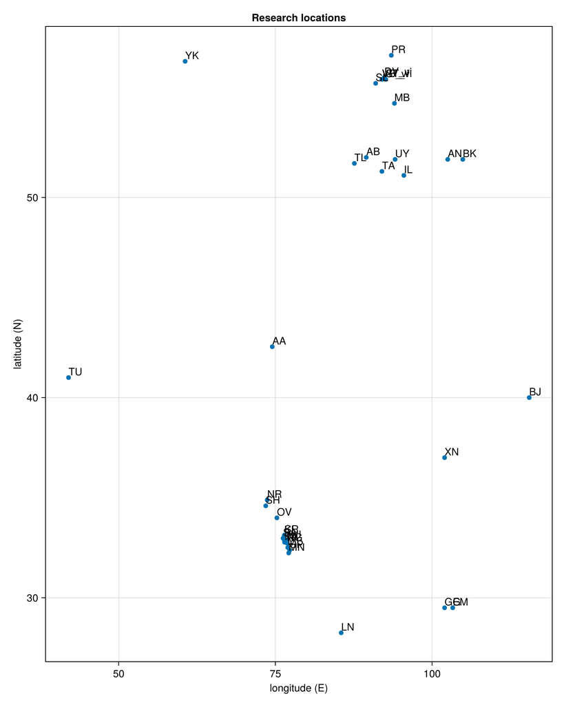

```julia
f = CairoMakie.Figure()
ax = Axis(f[1, 1],
    title = "Research locations",
    xlabel = "longitude (E)",
    ylabel = "latitude (N)"
)
scatter!(latlongs.long_E, latlongs.lat_N)
text!(latlongs.long_E, latlongs.lat_N; text = latlongs.location_short)
f
```

(*Ignore the warning that likely appears above. It is caused by an interaction between Quarto and the Makie graphing package, but has no consequence.*)

#### remove “Green warbler” *nitidus*

*Phylloscopus [t.] nitidus* is outside of the main ring, so remove these samples from this analysis:

```julia
latlongs2 = latlongs[Not(latlongs.subspecies .== "nitidus"), :];
print(latlongs2)
```

```
36×5 DataFrame
 Row │ Location_name               location_short  lat_N    long_E    subspecies
     │ String31                    String7         Float64  Float64   String15
─────┼──────────────────────────────────────────────────────────────────────────────
   1 │ Yekaterinburg               YK               56.8     60.6     viridanus
   2 │ Abakan                      AB               52.0     89.5     viridanus
   3 │ Teletsk                     TL               51.7     87.6     viridanus
   4 │ Verkh_Biryusa_vir           VB_vi            55.9     92.0     viridanus
   5 │ Divnogorsk_vir              DV_vi            56.0     92.4     viridanus
   6 │ Stolbi_vir                  ST_vi            55.9     92.6     viridanus
   7 │ Ala_Archa                   AA               42.54    74.5     viridanus
   8 │ Naran_Pakistan              NR               34.884   73.691   ludlowi
   9 │ Shogran_Pakistan            SH               34.594   73.466   ludlowi
  10 │ Overa_Kashmir               OV               33.991   75.243   ludlowi
  11 │ Satharundhi_ChambaDistrict  SA               32.974   76.222   ludlowi
```

[output cut: 25 more lines]

#### Make a matrix of great circle distances

These are Haversine distances, assuming spherical Earth which is really close:

```julia
geoPoints = GeoLocation.(latlongs2.long_E, latlongs2.lat_N)
# this next line is so neat--uses list comprehension to make a matrix of pairwise calculations
distances = [(HaversineDistance(geoPoints[i], geoPoints[j])/1000) for i in eachindex(geoPoints), j in eachindex(geoPoints)]
```

```
36×36 Matrix{Float64}:
    0.0   1929.03   1829.5    1920.28    …  1956.21    1976.01   1866.47
 1929.03     0.0     134.698   463.414       478.643    622.753   422.996
 1829.5    134.698     0.0     548.935       570.583    711.032   497.776
 1920.28   463.414   548.935     0.0          37.404    162.101    66.3387
 1941.17   483.376   572.19     27.2735       16.6941   139.661    93.5371
 1956.21   478.643   570.583    37.404   …     0.0      144.411   102.442
 1866.88  1539.57   1417.12   1943.75       1971.61    2101.68   1883.0
 2629.03  2280.66   2174.21   2720.63       2744.17    2882.26   2664.81
 2653.46  2318.81   2212.24   2758.56       2782.15    2920.16   2702.67
 2768.57  2304.58   2204.89   2753.66       2775.3     2915.75   2700.28
 2905.38  2370.69   2276.33   2825.06    …  2845.24    2987.08   2773.58
 2897.44  2350.4    2256.5    2805.15       2825.21    2967.15   2753.85
 2927.82  2377.48   2284.21   2832.75       2852.64    2994.71   2781.67
    ⋮                                    ⋱                          ⋮
 4317.27  2390.71   2499.26   2464.31       2434.21    2474.86   2502.82
 2869.29  1053.52   1187.02    953.003   …   918.603    934.047  1003.57
 2724.34   889.835  1023.03    817.872       785.302    818.533   863.881
 2341.58   426.63    551.809   581.592       567.027    679.716   591.859
 2117.8    189.217   307.752   511.497       513.021    652.226   493.694
 2214.04   315.404   447.369   465.516       455.478    579.504   468.914
 2082.09   423.338   540.944   183.922   …   160.175    268.68    220.448
 1920.28   463.414   548.935     0.0          37.404    162.101    66.3387
 1941.17   483.376   572.19     27.2735       16.6941   139.661    93.5371
 1956.21   478.643   570.583    37.404         0.0      144.411   102.442
 1976.01   622.753   711.032   162.101       144.411      0.0     218.833
 1866.47   422.996   497.776    66.3387  …   102.442    218.833     0.0
```

#### Now adjust distances to assume no gene flow through centre of ring.

```julia
# get some key distances
function getIndex(name; nameVector = latlongs2.Location_name)
    findfirst(isequal(name), nameVector)
end

index_AA = getIndex("Ala_Archa")
index_NR = getIndex("Naran_Pakistan")
index_LN = getIndex("Langtang")
index_GG = getIndex("Gongga")
index_XN = getIndex("Xining")
index_BJ = getIndex("Beijing")
index_last = nrow(latlongs2)

dist_NR_to_LN = distances[index_NR, index_LN]
dist_LN_to_GG = distances[index_LN, index_GG]
dist_GG_to_BJ = distances[index_GG, index_BJ]

# This next part will assume locations in the input file are arranged in order around ring:
distsAroundRing = Matrix{Float32}(undef, size(distances)[1], size(distances)[2])

# function for accepting straight-line great circle dists as distances between sets of sites
acceptDists = function(straightGreatCircleDists, start, finish, distsAroundRing)
    distsAroundRing[start:finish, start:finish] = straightGreatCircleDists[start:finish, start:finish]
    return(distsAroundRing)
end

# accept all distances within viridanus:
distsAroundRing = acceptDists(distances, 1, index_AA, distsAroundRing)

# accept dist from AA to NR:
distsAroundRing = acceptDists(distances, index_AA, index_NR, distsAroundRing)

# accept all distances from NR to LN:
distsAroundRing = acceptDists(distances, index_NR, index_LN, distsAroundRing)

# accept dist from LN to GG:
distsAroundRing = acceptDists(distances, index_LN, index_GG, distsAroundRing)

# accept dists between GG, EM, XN, BJ:
distsAroundRing = acceptDists(distances, index_GG, index_BJ, distsAroundRing)

# accept all distances within plumbeitarsus:
distsAroundRing = acceptDists(distances, index_BJ, index_last, distsAroundRing)

# function for adding up distances measured through certain sites:
addDists = function(set1start, set1end, set2start, set2end, distsAroundRing)
    firstDists = repeat(distsAroundRing[set1start:(set1end-1), set1end], 1, set2end-set2start+1)
    secondDists = repeat(transpose(distsAroundRing[set1end, set2start:set2end]), set1end-set1start, 1)
    totalDists = firstDists + secondDists
    distsAroundRing[set1start:(set1end-1), set2start:set2end] = totalDists
    distsAroundRing[set2start:set2end, set1start:(set1end-1)] = transpose(totalDists)
    return(distsAroundRing)
end

# dists from viridanus to NR are sum of dists to AA plus AA to NR:
distsAroundRing = addDists(1, index_AA, index_NR, index_NR, distsAroundRing)

# dists from "northwest of PK" to Himalayas are sum of ringdists to NR plus NR to locations up to LN:
distsAroundRing = addDists(1, index_NR, index_NR+1, index_LN, distsAroundRing)

# dists from "west / northwest of LN" to GG are sum of dists to LN plus LN to EM:
distsAroundRing = addDists(1, index_LN, index_GG, index_GG, distsAroundRing)

# dists from "west / northwest of EM" to China are sum of dists to GG plus GG to (EM, XN, BJ):
distsAroundRing = addDists(1, index_GG, index_GG, index_BJ, distsAroundRing)

# dists from "west of BJ" to east Siberia are sum of dists to BJ plus BJ to other plumbeitarsus:
distsAroundRing = addDists(1, index_BJ, index_BJ+1, index_last, distsAroundRing);
```

#### Do Principal Coordinates Analysis on the distances around the ring

This produces a single location axis around ring, going from west Siberia south, then east, then north to east Siberia.

```julia
PCO_around_ring = fit(MDS, distsAroundRing; distances=true, maxoutdim=1)
# add this as a column to the data frame:
latlongs2.LocationAroundRing = vec(-predict(PCO_around_ring))
latlongs2[:, [:location_short, :LocationAroundRing]]
println(latlongs2[:, [:location_short, :LocationAroundRing]])
```

```
36×2 DataFrame
 Row │ location_short  LocationAroundRing
     │ String7         Float32
─────┼────────────────────────────────────
   1 │ YK                       -4799.38
   2 │ AB                       -4548.43
   3 │ TL                       -4428.78
   4 │ VB_vi                    -4953.25
   5 │ DV_vi                    -4978.83
   6 │ ST_vi                    -4980.5
   7 │ AA                       -3027.02
   8 │ NR                       -2171.62
   9 │ SH                       -2166.63
  10 │ OV                       -1998.24
  11 │ SA                       -1861.95
```

[output cut: 25 more lines]

Add these ring locations to the metadata table:

```julia
GW_GenoData_indFiltered.indInfo.ring_km .= NaN  # pre-allocate the column
for i in axes(latlongs2, 1)
    match_indices = findall(GW_GenoData_indFiltered.indInfo.location .== latlongs2.location_short[i])
    GW_GenoData_indFiltered.indInfo.ring_km[match_indices] .= latlongs2.LocationAroundRing[i];
end
```

#### Make a table of locations and groups of individuals included after filtering

```julia
gdf = groupby(GW_GenoData_indFiltered.indInfo, [:location, :Fst_group])
sample_origin_summary = combine(gdf, nrow)
println(sample_origin_summary)
# to save as comma-delimited text:
# CSV.write("GW2025_sample_origin_summary.txt", sample_origin_summary; delim='\t')
```

```
37×3 DataFrame
 Row │ location  Fst_group    nrow
     │ String7   String15     Int64
─────┼──────────────────────────────
   1 │ AB        vir              2
   2 │ ST        plumb           35
   3 │ ST        plumb_vir        1
   4 │ ST_vi     vir              6
   5 │ DV        plumb            5
   6 │ DV_vi     vir              2
   7 │ MB        plumb            4
   8 │ VB        plumb            5
   9 │ PR        plumb            5
  10 │ BJ        plumb_BJ         3
  11 │ TL        vir             11
```

[output cut: 26 more lines]

### Save the filtered dataset and other info for other Quarto pages

```julia
cd(dataDirectory)
filename = string(baseName, tagName, "ind_SNP_ind_filtered.jld2")
jldsave(filename; GW_GenoData_indFiltered,
                    repoDirectory,
                    dataDirectory,
                    scaffold_info,
                    scaffold_lengths,
                    baseName,
                    filenameTextMiddle,
                    missingGenotypeThreshold,
                    filenameTextEnd,
                    tagName,
                    chromosomes_to_process,
                    metadataFile)
println("Saved the filtered data.")
```

```
Saved the filtered data.
```

The above saves the important data for other Quarto pages, which will load data as below:

#### Load the filtered dataset

(This block is not active here)

```julia
filename = string(baseName, tagName, "ind_SNP_ind_filtered.jld2")
# load info into a dictionary:
d = load(filename)
GW_GenoData_indFiltered = d["GW_GenoData_indFiltered"]
repoDirectory = d["repoDirectory"]
dataDirectory = d["dataDirectory"]
scaffold_info = d["scaffold_info"]
scaffold_lengths = d["scaffold_lengths"]
baseName = d["baseName"]
filenameTextMiddle = d["filenameTextMiddle"]
missingGenotypeThreshold = d["missingGenotypeThreshold"]
filenameTextEnd = d["filenameTextEnd"]
tagName = d["tagName"]
chromosomes_to_process = d["chromosomes_to_process"]
metadataFile = ["metadataFile"]
```

## Genotype-by-individual plots

Now, show individual genotypes for subsets of the dataset. Can choose individuals and genomic regions to plot, along with an Fst cutoff (only show SNPs with greater Fst than the cutoff).

```julia
groups = ["vir","plumb"]
plotGroups = ["vir","plumb_vir","plumb"]
plotGroupColors = ["blue","purple","red"]
numIndsToPlot = [100,100,100] # maximum number of individuals to plot from each group
group1 = "vir"   # these groups will determine the color used in the graph
group2 = "plumb"
groupsToCompare = "vir_plumb"
Fst_cutoff =  0.8
missingFractionAllowed = 0.2;  # only show SNPs with less than this fraction of missing data among individuals
```

#### Calculate allele freqs and sample sizes

This uses groups indicated column `Fst_group` in the metadata file.

```julia
freqs, sampleSizes = GenomicDiversity.getFreqsAndSampleSizes(GW_GenoData_indFiltered, groups)
println("Calculated population allele frequencies and sample sizes")
```

```
Calculated population allele frequencies and sample sizes
```

#### Calculate Fst

```julia
Fst, FstNumerator, FstDenominator, pairwiseNamesFst = GenomicDiversity.getFst(freqs,
                                    sampleSizes, groups)
println("Calculated Fst values")
```

```
Calculated Fst values
```

#### Limit the individuals to include in plot

```julia
# Limit each group to specified numbers
genotypes_included, indInfo_included = limitIndsToPlot(plotGroups, numIndsToPlot, GW_GenoData_indFiltered.genotypes, GW_GenoData_indFiltered.indInfo)
# put the info for limited individuals into new GenoData object
GW_GenoData_indFiltered_included = GenoData(indInfo_included, genotypes_included, GW_GenoData_indFiltered.positions);
# Note to self: make this function more streamlined in next version of package,
# so that limitIndsToPlot() can work directly on a GenoData object.
```

#### Choose the scaffold and region to show

```julia
chr = "gw23"
# get the maximum position for the chromosome, for use later:
regionInfo = GenomicDiversity.chooseChrRegion(GW_GenoData_indFiltered_included.positions, chr;
        positionMin=1, positionMax=scaffold_lengths[chr])
```

```
("gw23", 1, 8435933, "chr gw23 1 to 8435933")
```

#### Now actually make the plot

```
┌ Warning: Found `resolution` in the theme when creating a `Scene`. The `resolution` keyword for `Scene`s and `Figure`s has been deprecated. Use `Figure(; size = ...` or `Scene(; size = ...)` instead, which better reflects that this is a unitless size and not a pixel resolution. The key could also c…
└ @ Makie ~/.julia/packages/Makie/Y3ABD/src/scenes.jl:238
```

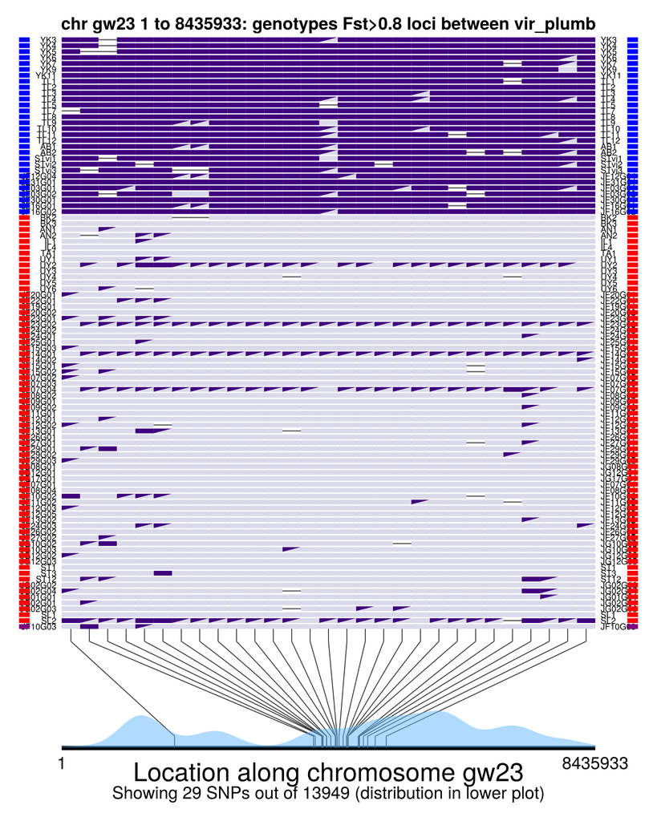

```julia
plotInfo = GenomicDiversity.plotGenotypeByIndividualWithFst(GW_GenoData_indFiltered_included,
    groupsToCompare, Fst_cutoff, missingFractionAllowed,
    regionInfo, Fst, pairwiseNamesFst,
    freqs, plotGroups, plotGroupColors);
# plotInfo contains a tuple with: (f, plottedGenotype, locations, plottedMetadata)
```

#### Choose another chromosome, and plot similarly to above

```
┌ Warning: Found `resolution` in the theme when creating a `Scene`. The `resolution` keyword for `Scene`s and `Figure`s has been deprecated. Use `Figure(; size = ...` or `Scene(; size = ...)` instead, which better reflects that this is a unitless size and not a pixel resolution. The key could also c…
└ @ Makie ~/.julia/packages/Makie/Y3ABD/src/scenes.jl:238
```

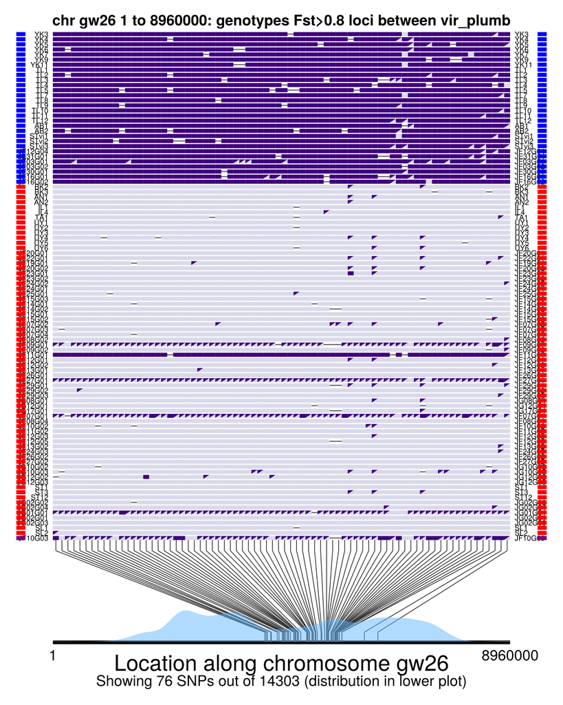

```julia
chr = "gw26"
regionInfo = chooseChrRegion(GW_GenoData_indFiltered_included.positions, chr; positionMin=1, positionMax=scaffold_lengths[chr])
plotInfo = GenomicDiversity.plotGenotypeByIndividualWithFst(GW_GenoData_indFiltered_included,
    groupsToCompare, Fst_cutoff, missingFractionAllowed,
    regionInfo, Fst, pairwiseNamesFst,
    freqs, plotGroups, plotGroupColors);
```

#### Make a GBI plot to illustrate variation along west side of ring

```
Calculated population allele frequencies and sample sizes
Calculated Fst values
```

```
┌ Warning: Found `resolution` in the theme when creating a `Scene`. The `resolution` keyword for `Scene`s and `Figure`s has been deprecated. Use `Figure(; size = ...` or `Scene(; size = ...)` instead, which better reflects that this is a unitless size and not a pixel resolution. The key could also c…
└ @ Makie ~/.julia/packages/Makie/Y3ABD/src/scenes.jl:238
```

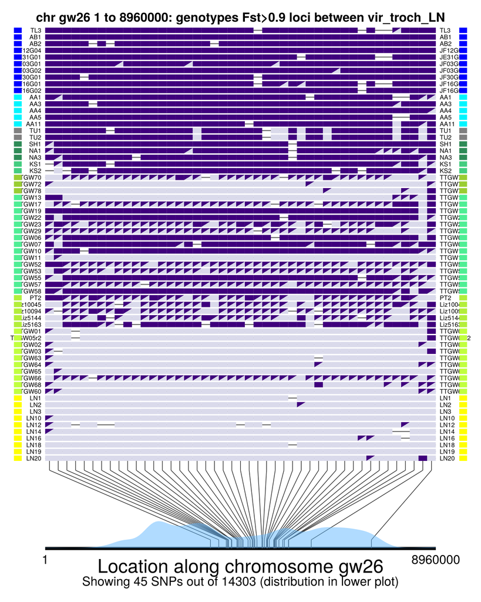

```julia
groups = ["vir","troch_LN"] # for purpose of calculating pairwise Fst and Fst_group (to determine SNPs)
plotGroups = ["vir","vir_S","nit", "lud_PK", "lud_KS", "lud_central", "lud_Sath", "lud_ML","troch_west","troch_LN"]
plotGroupColors = ["blue","turquoise1","grey","seagreen4","seagreen3","seagreen2","olivedrab3","olivedrab2","olivedrab1","yellow"]
numIndsToPlot = [10, 5, 2, 3, 5, 15, 3, 5, 10, 10] # maximum number of individuals to plot from each group
group1 = "vir"   # these groups will determine the color used in the graph
group2 = "troch_LN"
groupsToCompare = "vir_troch_LN" # "Fst_among"
Fst_cutoff = 0.9
missingFractionAllowed = 0.2  # only show SNPs with less than this fraction of missing data among individuals

# Calculate allele freqs and sample sizes (use column Fst_group)
freqs, sampleSizes = GenomicDiversity.getFreqsAndSampleSizes(GW_GenoData_indFiltered, groups)
println("Calculated population allele frequencies and sample sizes")

# calculate Fst
Fst, FstNumerator, FstDenominator, pairwiseNamesFst = GenomicDiversity.getFst(freqs,
                                    sampleSizes, groups)
println("Calculated Fst values")

# Limit each group to specified numbers
genotypes_included, indInfo_included = limitIndsToPlot(plotGroups, numIndsToPlot, GW_GenoData_indFiltered.genotypes, GW_GenoData_indFiltered.indInfo)
# put the info for limited individuals into new GenoData object
GW_GenoData_indFiltered_included = GenoData(indInfo_included, genotypes_included, GW_GenoData_indFiltered.positions);

# choose the scaffold and region to show
chr = "gw26"
regionInfo = chooseChrRegion(GW_GenoData_indFiltered_included.positions, chr; positionMin=1, positionMax=scaffold_lengths[chr])

#### Now actually make the plot
plotInfo = GenomicDiversity.plotGenotypeByIndividualWithFst(GW_GenoData_indFiltered_included,
    groupsToCompare, Fst_cutoff, missingFractionAllowed,
    regionInfo, Fst, pairwiseNamesFst,
    freqs, plotGroups, plotGroupColors);
```

#### Show another chromosome along west side of ring:

```
┌ Warning: Found `resolution` in the theme when creating a `Scene`. The `resolution` keyword for `Scene`s and `Figure`s has been deprecated. Use `Figure(; size = ...` or `Scene(; size = ...)` instead, which better reflects that this is a unitless size and not a pixel resolution. The key could also c…
└ @ Makie ~/.julia/packages/Makie/Y3ABD/src/scenes.jl:238
```

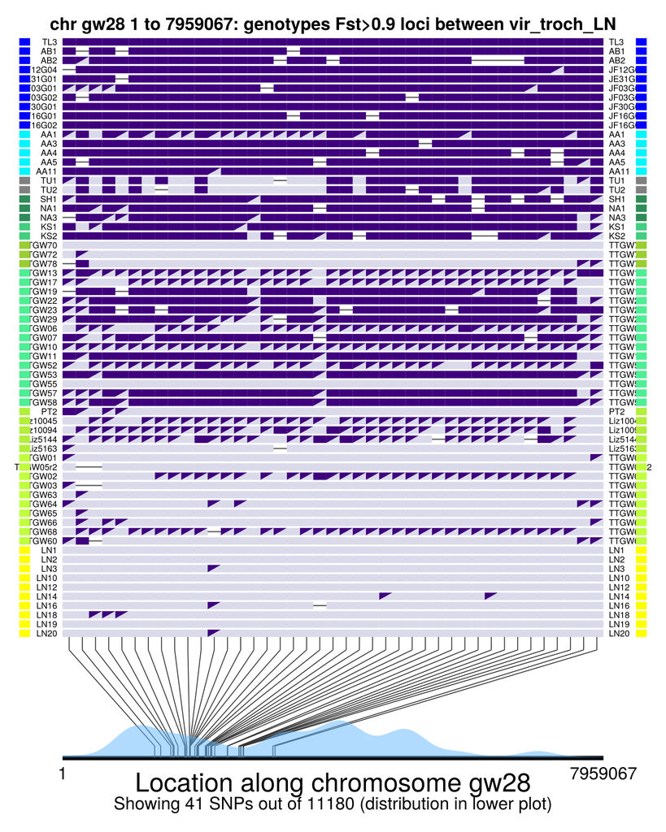

```julia
# choose the scaffold and region to show
chr = "gw28"
regionInfo = chooseChrRegion(GW_GenoData_indFiltered_included.positions, chr; positionMin=1, positionMax=scaffold_lengths[chr])

#### Now actually make the plot
plotInfo = GenomicDiversity.plotGenotypeByIndividualWithFst(GW_GenoData_indFiltered_included,
    groupsToCompare, Fst_cutoff, missingFractionAllowed,
    regionInfo, Fst, pairwiseNamesFst,
    freqs, plotGroups, plotGroupColors);
```

#### Make a GBI plot to illustrate variation along east side of ring

```
Calculated population allele frequencies and sample sizes
Calculated Fst values
Specific individuals filtered out:
```

```
2-element Vector{String}:
 "GW_Armando_plate1_JF09G01"
 "GW_Armando_plate1_JF24G02"
```

```
┌ Warning: Found `resolution` in the theme when creating a `Scene`. The `resolution` keyword for `Scene`s and `Figure`s has been deprecated. Use `Figure(; size = ...` or `Scene(; size = ...)` instead, which better reflects that this is a unitless size and not a pixel resolution. The key could also c…
└ @ Makie ~/.julia/packages/Makie/Y3ABD/src/scenes.jl:238
```

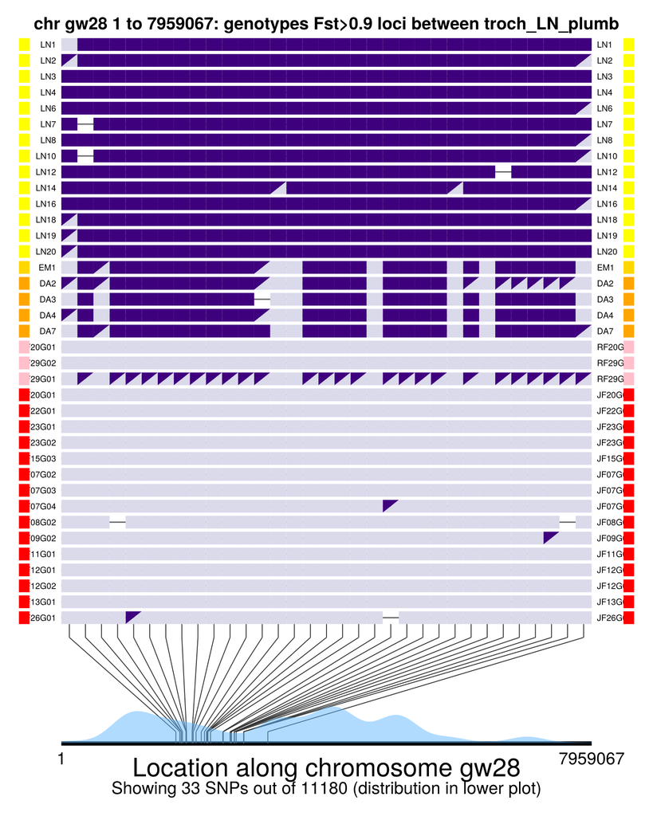

```julia
groups = ["troch_LN","obs","plumb"] # for purpose of calculating pairwise Fst and Fst_group (to determine SNPs)
plotGroups = ["troch_LN","troch_EM","obs","plumb_BJ","plumb"]
plotGroupColors = ["yellow","gold","orange","pink","red"]
numIndsToPlot = [15, 15, 15, 15, 17] # maximum number of individuals to plot from each group
group1 = "troch_LN"   # these groups will determine the color used in the graph
group2 = "plumb"
groupsToCompare = "troch_LN_plumb" #"troch_LN_plumb" #"Fst_among"
Fst_cutoff = 0.9
missingFractionAllowed = 0.2  # only show SNPs with less than this fraction of missing data among individuals

# Calculate allele freqs and sample sizes (use column Fst_group)
freqs, sampleSizes = GenomicDiversity.getFreqsAndSampleSizes(GW_GenoData_indFiltered, groups)
println("Calculated population allele frequencies and sample sizes")

# calculate Fst
Fst, FstNumerator, FstDenominator, pairwiseNamesFst = GenomicDiversity.getFst(freqs,
                                    sampleSizes, groups)
println("Calculated Fst values")

# Limit each group to specified numbers
genotypes_included, indInfo_included = limitIndsToPlot(plotGroups, numIndsToPlot, GW_GenoData_indFiltered.genotypes, GW_GenoData_indFiltered.indInfo)
# put the info for limited individuals into new GenoData object
GW_GenoData_indFiltered_included = GenoData(indInfo_included, genotypes_included, GW_GenoData_indFiltered.positions);

# choose the scaffold and region to show
chr = "gw28"
regionInfo = chooseChrRegion(GW_GenoData_indFiltered_included.positions, chr; positionMin=1, positionMax=scaffold_lengths[chr])

# need to remove two plumbeitarsus individuals that have introgression from viridanus, as that would otherwise be misleading in this figure since viridanus are not shown
GW_GenoData_indFiltered_included_minus2 = GenomicDiversity.filterNamedInds(GW_GenoData_indFiltered_included,
            ["GW_Armando_plate1_JF09G01", "GW_Armando_plate1_JF24G02"]);

#### Now actually make the plot
plotInfo = GenomicDiversity.plotGenotypeByIndividualWithFst(GW_GenoData_indFiltered_included_minus2,
    groupsToCompare, Fst_cutoff, missingFractionAllowed,
    regionInfo, Fst, pairwiseNamesFst,
    freqs, plotGroups, plotGroupColors);
```

## Make GBI plots showing all individuals in the study

```julia
groups_to_plot_all = ["vir","vir_S","nit", "lud_PK", "lud_KS", "lud_central", "lud_Sath", "lud_ML","troch_west","troch_LN","troch_EM","obs","plumb_BJ","plumb","plumb_vir"]
group_colors_all = ["blue","turquoise1","grey","seagreen4","seagreen3","seagreen2","olivedrab3","olivedrab2","olivedrab1","yellow","gold","orange","pink","red","purple"];
```

This will use Fst among multiple groups to determine SNPs to plot. For chr 28:

```
Calculated population allele frequencies and sample sizes
Calculated Fst values
```

```
┌ Warning: Found `resolution` in the theme when creating a `Scene`. The `resolution` keyword for `Scene`s and `Figure`s has been deprecated. Use `Figure(; size = ...` or `Scene(; size = ...)` instead, which better reflects that this is a unitless size and not a pixel resolution. The key could also c…
└ @ Makie ~/.julia/packages/Makie/Y3ABD/src/scenes.jl:238
```

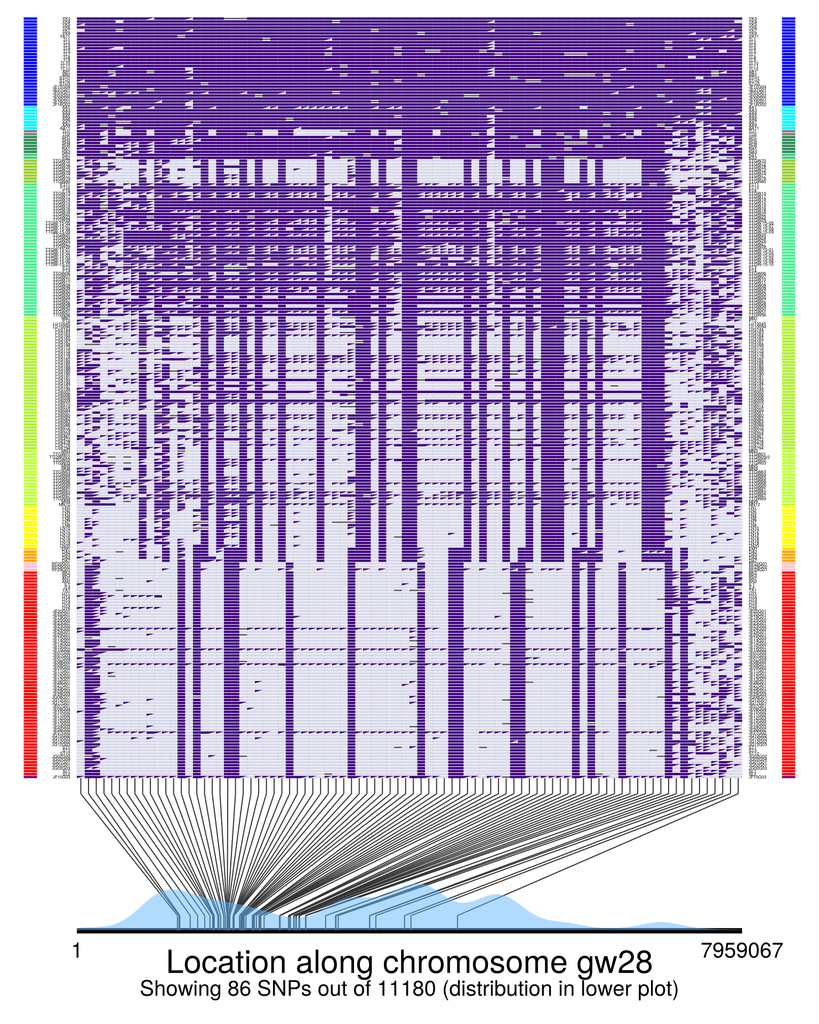

```julia
groups = ["vir","lud_PK","troch_LN","obs","plumb"] # for purpose of calculating pairwise Fst and Fst_group (to determine SNPs)
plotGroups = groups_to_plot_all
plotGroupColors = group_colors_all
group1 = "vir"   # these groups will determine the color used in the graph
group2 = "plumb"
groupsToCompare = ["vir_plumb", "vir_troch_LN", "troch_LN_plumb"]     # "Fst_among" #"vir_plumb"
Fst_cutoff = 0.8
missingFractionAllowed = 0.2  # only show SNPs with less than this fraction of missing data among individuals

# Calculate allele freqs and sample sizes (use column Fst_group)
freqs, sampleSizes = GenomicDiversity.getFreqsAndSampleSizes(GW_GenoData_indFiltered, groups)
println("Calculated population allele frequencies and sample sizes")

Fst, FstNumerator, FstDenominator, pairwiseNamesFst = GenomicDiversity.getFst(freqs,
                                    sampleSizes, groups)
println("Calculated Fst values")

chr = "gw28"
regionInfo = chooseChrRegion(GW_GenoData_indFiltered.positions, chr; positionMin=1, positionMax=scaffold_lengths[chr]) # this gets the maximum position for the chromosome

plotInfo = GenomicDiversity.plotGenotypeByIndividualWithFst(GW_GenoData_indFiltered,
    groupsToCompare, Fst_cutoff, missingFractionAllowed,
    regionInfo, Fst, pairwiseNamesFst,
    freqs, groups_to_plot_all, group_colors_all;
    indFontSize=4, figureSize=(1200,1600),
    plotTitle = "");
```

#### Make list of scaffolds to plot according to above:

```julia
scaffolds_to_plot = "gw" .* string.(vcat(28:-1:17, 15:-1:1))
push!(scaffolds_to_plot, "gw1A", "gw4A")  # add two other scaffolds
```

```
29-element Vector{String}:
 "gw28"
 "gw27"
 "gw26"
 "gw25"
 "gw24"
 "gw23"
 "gw22"
 "gw21"
 "gw20"
 "gw19"
 "gw18"
 "gw17"
 "gw15"
 ⋮
 "gw10"
 "gw9"
 "gw8"
 "gw7"
 "gw6"
 "gw5"
 "gw4"
 "gw3"
 "gw2"
 "gw1"
 "gw1A"
 "gw4A"
```

Loop through each scaffold and produce GBI plot. (Making inactive because already saved figs and takes long.)

```julia
for i in 1:length(scaffolds_to_plot)
    chr = scaffolds_to_plot[i]
    regionInfo = chooseChrRegion(GW_GenoData_indFiltered, chr; positionMin=1, positionMax=scaffold_lengths[chr]) # this gets the maximum position for the chromosome
    plotInfo = GenomicDiversity.plotGenotypeByIndividualWithFst(GW_GenoData_indFiltered,
        groupsToCompare, Fst_cutoff, missingFractionAllowed,
        regionInfo, Fst, pairwiseNamesFst,
        freqs, plotGroups, plotGroupColors;
        indFontSize=4, figureSize=(1200,1600), plotTitle = "");
    println("Completed the figure for ", chr, ".")
    if false  # set to true to save plot
        filename = string("Figure_", chr, "_Fst3groups_GBI_allInds_from_Julia.png")
        save(filename, plotInfo[1], px_per_unit = 2.0)
        println("Saved ", filename)
    end
end
```

## Impute missing genotypes, for PCA

Our goal is to produce plots showing individuals in genotype space, using Principal Components Analysis.

PCA requires imputation of missing genotypes. I did imputation for each scaffold above a certain size threshold. These are listed in `chromosomes_to_process` .

Imputation can take several minutes per scaffold, so I ran this imputation step separately from this Quarto notebook (otherwise render would take long) and saved the genotype data for each scaffold for loading in the next step. There are two alternative algorithms that I’ve used for imputing: SVD (Singular Value Decomposition) and KNN (K Nearest Neighbours), both of which are implemented in the Impute.jl package. After much testing and thought, I decided to use KNN imputation (with K=1) on each chromosome, and then combine chromosomes for the genome-wide PCA. For PCAs of small genomic regions, I use SVD.

##### The code for SVD imputing is below (not actually used here):

```julia
for i in eachindex(chromosomes_to_process)
    chrom = chromosomes_to_process[i]
    regionText = string("chr", chrom)
    ind_with_metadata_indFiltered = GW_GenoData_indFiltered.indInfo
    loci_selection = (GW_GenoData_indFiltered.positions.chrom .== chrom)
    pos_SNP_filtered_region = GW_GenoData_indFiltered.positions[loci_selection,:]
    genosOnly_region_for_imputing = Matrix{Union{Missing, Float32}}(GW_GenoData_indFiltered.genotypes[:,loci_selection])
    @time imputed_genos = Impute.svd(genosOnly_region_for_imputing)
    filename = string(baseName, tagName, regionText, ".SVDimputedMissing.jld2")
    jldsave(filename; imputed_genos, ind_with_metadata_indFiltered, pos_SNP_filtered_region)
    println(string("Chromosome ", chrom, ": Saved real and imputed genotypes for ", size(pos_SNP_filtered_region, 1)," SNPs and ", size(genosOnly_region_for_imputing, 1)," individuals."))
end
```

#### Imputation using KNN

Troyanskaya *et al.* (2001) recommend imputation using K-nearest neighbors approach as being better than SVD, both of which are better than other methods for DNA genotyping. They also recommend using Euclidian distance. So I use KNN with Euclidian distance for imputation along whole chromosomes. I am going with setting `dims` to `:rows`, as that seems to run much faster and produces PCAs that make a lot of sense. I’ve already run this next code cell, which does the imputing and saves the imputed data matrix for each scaffold. This actually runs quite quickly–at most a couple minutes per scaffold. :)

```julia
for i in eachindex(chromosomes_to_process)
    chrom = chromosomes_to_process[i]
    regionText = string("chr", chrom)
    ind_with_metadata_indFiltered = GW_GenoData_indFiltered.indInfo
    loci_selection = (GW_GenoData_indFiltered.positions.chrom .== chrom)
    pos_SNP_filtered_region = GW_GenoData_indFiltered.positions[loci_selection,:]
    genosOnly_region_for_imputing = Matrix{Union{Missing, Float32}}(GW_GenoData_indFiltered.genotypes[:,loci_selection])
    @time imputed_genos = Impute.knn(genosOnly_region_for_imputing; dims = :rows) # much faster with the "dims = :rows" there
    filename = string(baseName, tagName, regionText, ".KNNimputedMissing.jld2")
    jldsave(filename; imputed_genos, ind_with_metadata_indFiltered, pos_SNP_filtered_region)
    println(string("Chromosome ", chrom, ": Saved real and imputed genotypes for ", size(pos_SNP_filtered_region, 1)," SNPs and ", size(genosOnly_region_for_imputing, 1)," individuals."))
end
```

Now we can cycle through a set of chromosomes and plot a PCA for each. We need to first specify some groups to include in the plot, and their colors:

```julia
groups_to_plot_PCA = ["vir","vir_S","nit", "lud_PK", "lud_KS", "lud_central", "lud_Sath", "lud_ML","troch_west","troch_LN","troch_EM","obs","plumb_BJ","plumb","plumb_vir"]
group_colors_PCA = ["blue","turquoise1","grey","seagreen4","seagreen3","seagreen2","olivedrab3","olivedrab2","olivedrab1","yellow","gold","orange","pink","red","purple"];
```

Now we can actually do the PCA and make the plot for each scaffold. (Making this inactive for now, because it makes a lot of plots.)

```julia
for i in eachindex(chromosomes_to_process)
    scaffold = chromosomes_to_process[i]
    regionText = string("chr", scaffold)
    filename = string(baseName, tagName, regionText, ".SVDimputedMissing.jld2")
    imputed_genos = load(filename, "imputed_genos")
    ind_with_metadata_indFiltered = load(filename, "ind_with_metadata_indFiltered")
    pos_SNP_filtered_region = load(filename, "pos_SNP_filtered_region")
    println(string("Loaded ",filename))
    println(string(regionText, ": ", size(imputed_genos,2), " SNPs from ", size(imputed_genos,1), " individuals"))
    flipPC1 = true
    flipPC2 = true
    PCAmodel = plotPCA(imputed_genos, ind_with_metadata_indFiltered,
            groups_to_plot_PCA, group_colors_PCA;
            sampleSet = "greenish warblers", regionText=regionText,
            flip1 = flipPC1, flip2 = flipPC2,
            lineOpacity = 0.7, fillOpacity = 0.6,
            symbolSize = 14, showTitle = true,
            xLabelText = string("Chromosome ", scaffold," PC1"), yLabelText = string("Chromosome ", scaffold," PC2"),
            showPlot = false)
    # add position of reference genome
    refGenomePCAposition = predict(PCAmodel.model, zeros(size(imputed_genos, 2)))
    flipPC1 && (refGenomePCAposition[1] *= -1)  # this flips PC1 if flipPC1 = true
    flipPC2 && (refGenomePCAposition[2] *= -1)  # same for PC2
    CairoMakie.scatter!(refGenomePCAposition[1], refGenomePCAposition[2], marker = :diamond, color="black", markersize=15, strokewidth=0.5)
    try
        display(PCAmodel.PCAfig)
    catch
        println("NOTICE: Figure for ", regionText, " could not be shown due to an unknown error.")
    end
end
```

#### More genotype-by-individual plots (some examples)

##### GBI plot showing just west individuals:

```
Calculated population allele frequencies and sample sizes
Calculated Fst values
```

```
┌ Warning: Found `resolution` in the theme when creating a `Scene`. The `resolution` keyword for `Scene`s and `Figure`s has been deprecated. Use `Figure(; size = ...` or `Scene(; size = ...)` instead, which better reflects that this is a unitless size and not a pixel resolution. The key could also c…
└ @ Makie ~/.julia/packages/Makie/Y3ABD/src/scenes.jl:238
```

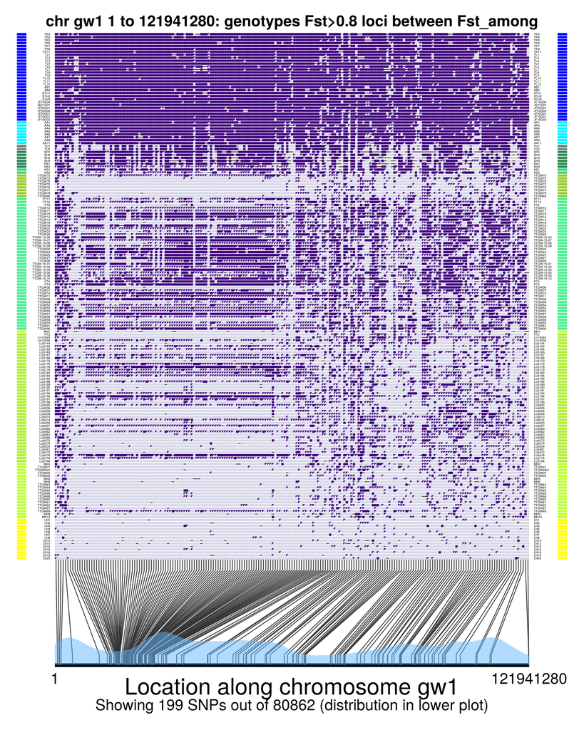

```
Completed the figure for gw1.
```

```julia
groups = ["vir","lud_PK","troch_LN"] # for purpose of calculating pairwise Fst and Fst_group (to determine SNPs)
plotGroups = ["vir", "vir_misID", "vir_S", "nit", "lud_PK", "lud_KS", "lud_central", "lud_Sath", "lud_ML", "troch_west", "troch_LN"] # west GW individuals
plotGroupColors = ["blue", "blue", "turquoise1", "grey", "seagreen4", "seagreen3", "seagreen2", "olivedrab3", "olivedrab2", "olivedrab1", "yellow"]
group1 = "vir"   # these groups will determine the color used in the graph
group2 = "troch_LN"
groupsToCompare = "Fst_among" #"vir_plumb"
Fst_cutoff = 0.8
missingFractionAllowed = 0.2  # only show SNPs with less than this fraction of missing data among individuals

# Calculate allele freqs and sample sizes (use column Fst_group)
freqs, sampleSizes = GenomicDiversity.getFreqsAndSampleSizes(GW_GenoData_indFiltered, groups)
println("Calculated population allele frequencies and sample sizes")

Fst, FstNumerator, FstDenominator, pairwiseNamesFst = GenomicDiversity.getFst(freqs,
                                    sampleSizes, groups;
                                    among=true)  # set among to FALSE if no among Fst wanted (some things won't work without it)
println("Calculated Fst values")

scaffolds_to_plot = ["gw1"]

for i in 1:length(scaffolds_to_plot)
    chr = scaffolds_to_plot[i]
    regionInfo = chooseChrRegion(GW_GenoData_indFiltered.positions, chr; positionMin=1, positionMax=scaffold_lengths[chr]) # this gets the maximum position for the chromosome
    plotInfo = GenomicDiversity.plotGenotypeByIndividualWithFst(GW_GenoData_indFiltered,
                groupsToCompare, Fst_cutoff, missingFractionAllowed,
                regionInfo, Fst, pairwiseNamesFst,
                freqs, plotGroups, plotGroupColors;
                indFontSize=4, figureSize=(1200,1600));
    println("Completed the figure for ", chr, ".")
end
```

##### Make GBI plots showing just east individuals:

```
Calculated population allele frequencies and sample sizes
Calculated Fst values
```

```
┌ Warning: Found `resolution` in the theme when creating a `Scene`. The `resolution` keyword for `Scene`s and `Figure`s has been deprecated. Use `Figure(; size = ...` or `Scene(; size = ...)` instead, which better reflects that this is a unitless size and not a pixel resolution. The key could also c…
└ @ Makie ~/.julia/packages/Makie/Y3ABD/src/scenes.jl:238
```

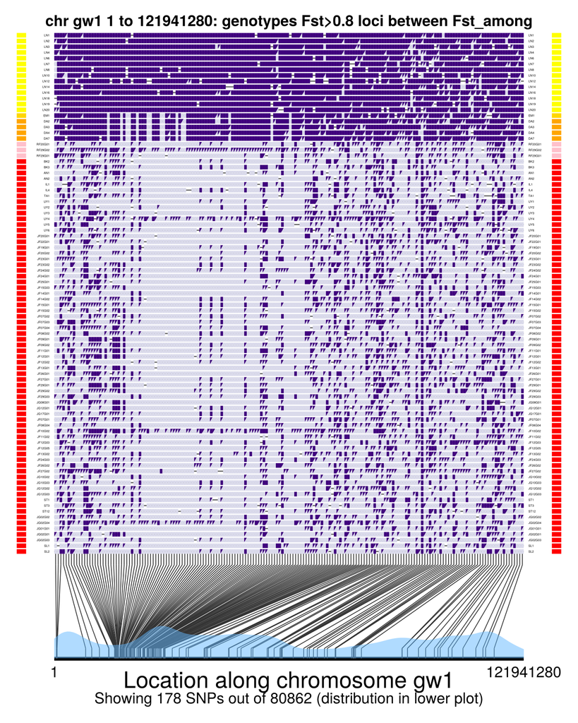

```
Completed the figure for gw1.
```

```julia
groups = ["troch_LN","obs","plumb"] # for purpose of calculating pairwise Fst and Fst_group (to determine SNPs)
plotGroups = ["troch_LN", "troch_EM", "obs", "plumb_BJ", "plumb"] # east GW individuals
plotGroupColors = ["yellow", "gold", "orange", "pink", "red"]
group1 = "troch_LN"   # these groups will determine the color used in the graph
group2 = "plumb"
groupsToCompare = "Fst_among" #"vir_plumb"
Fst_cutoff = 0.8
missingFractionAllowed = 0.2  # only show SNPs with less than this fraction of missing data among individuals

# Calculate allele freqs and sample sizes (use column Fst_group)
freqs, sampleSizes = GenomicDiversity.getFreqsAndSampleSizes(GW_GenoData_indFiltered, groups)
println("Calculated population allele frequencies and sample sizes")

Fst, FstNumerator, FstDenominator, pairwiseNamesFst = GenomicDiversity.getFst(freqs,
                                    sampleSizes, groups;
                                    among=true)  # set among to FALSE if no among Fst wanted (some things won't work without it)
println("Calculated Fst values")

for i in 1:length(scaffolds_to_plot)
    chr = scaffolds_to_plot[i]
    regionInfo = chooseChrRegion(GW_GenoData_indFiltered.positions, chr; positionMin=1, positionMax=scaffold_lengths[chr])
    plotInfo = GenomicDiversity.plotGenotypeByIndividualWithFst(GW_GenoData_indFiltered,
                groupsToCompare, Fst_cutoff, missingFractionAllowed,
                regionInfo, Fst, pairwiseNamesFst,
                freqs, plotGroups, plotGroupColors;
                indFontSize=4, figureSize=(1200,1600));
    println("Completed the figure for ", chr, ".")
end
```